# Uncanny Valley - Manuscript

Kimberly A. Brink

June 30, 2016

### Survey Questions

Uncanny Valley 1: Do you feel the robot is creepy?

Uncanny Valley 2: Does the robot make you feel weird?

Uncanny Valley 3: Would you want to play with the robot?

Agency 1: Can the robot do things on purpose?

Agency 2: When the robot moves does it choose to move?

Internal State 1: Does the robot think for itself?

Internal State 2: Does the robot know the difference between good and bad?

Internal State 3: Would the robot feel pain?

Internal State 4: Does the robot have feelings?

Internal State 5: Would the robot feel scared?

Internal State 6: Would the robot feel hungry?

Human-likeness 1: Is this robot like a human?

Exploratory 1: Does the robot know it’s a robot?

## Age Breakdown

| 1 | 2 | 3 | 4 |
| --- | --- | --- | --- |
| 51 | 97 | 55 | 36 |

| 0 | 1 |
| --- | --- |
| 25 | 26 |
| 47 | 50 |
| 35 | 20 |
| 15 | 21 |

| Group.1 | x |
| --- | --- |
| 1 | 4.961 |
| 2 | 7.538 |
| 3 | 10.52 |
| 4 | 13.8 |

| Group.1 | x |
| --- | --- |
| 1 | 3.111 |
| 2 | 6.008 |
| 3 | 9 |
| 4 | 12.02 |

| Group.1 | x |
| --- | --- |
| 1 | 5.997 |
| 2 | 8.942 |
| 3 | 11.97 |
| 4 | 17.61 |

## Exploratory factor analysis for Kaspar Back

Factor analysis with nonorthogonal promax rotation

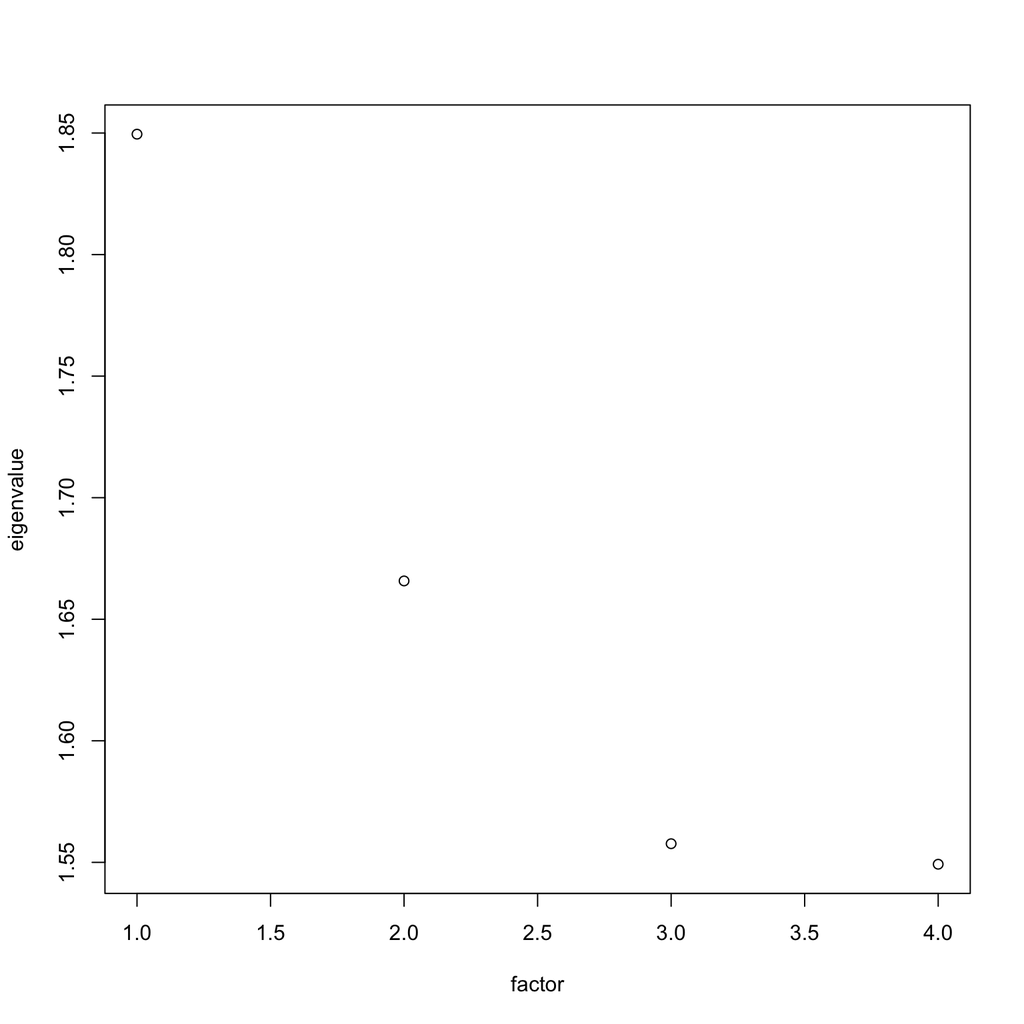

```
##
## Call:
## factanal(x = na.omit(UV[Q.Back]), factors = 3, scores = "regression",     rotation = "promax")
##
## Uniquenesses:
## UV1.Back UV2.Back UV3.Back  A1.Back  A2.Back IS1.Back IS2.Back IS3.Back
##     0.57     0.45     0.57     0.97     0.68     0.52     0.42     0.14
## IS4.Back IS5.Back IS6.Back  E1.Back HL1.Back
##     0.40     0.67     0.50     0.49     0.80
##
## Loadings:
##          Factor1 Factor2 Factor3
## A2.Back   0.52            0.13
## IS1.Back  0.71
## IS2.Back  0.77
## IS4.Back  0.64    0.18
## IS3.Back -0.25    1.08
## IS6.Back  0.25    0.52
## UV1.Back -0.17            0.61
## UV2.Back  0.20            0.75
## UV3.Back  0.18   -0.10   -0.61
## A1.Back   0.22   -0.14    0.11
## IS5.Back  0.21    0.42
## E1.Back   0.43    0.36
## HL1.Back          0.25   -0.32
##
##                Factor1 Factor2 Factor3
## SS loadings       2.28    1.87    1.48
## Proportion Var    0.18    0.14    0.11
## Cumulative Var    0.18    0.32    0.43
##
## Factor Correlations:
##         Factor1 Factor2 Factor3
## Factor1  1.0000 -0.0077   -0.66
## Factor2 -0.0077  1.0000   -0.15
## Factor3 -0.6649 -0.1450    1.00
##
## Test of the hypothesis that 3 factors are sufficient.
## The chi square statistic is 47.65 on 42 degrees of freedom.
## The p-value is 0.254
```

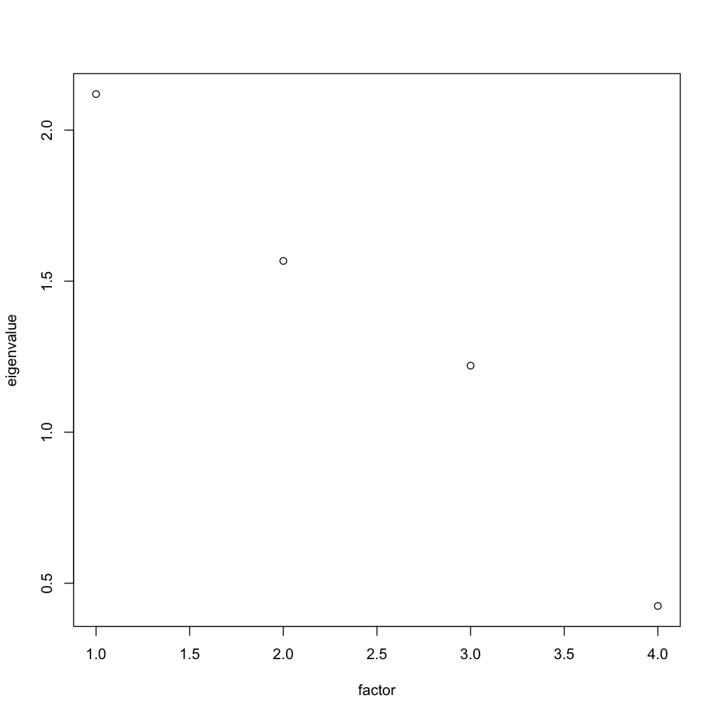

```
##
## Call:
## factanal(x = na.omit(UV[Q.Back]), factors = 3, scores = "regression",     rotation = "promax")
##
## Uniquenesses:
## UV1.Back UV2.Back  A2.Back IS1.Back IS2.Back IS3.Back IS5.Back IS6.Back
##     0.14     0.75     0.62     0.43     0.52     0.15     0.66     0.54
##
## Loadings:
##          Factor1 Factor2 Factor3
## A2.Back   0.62
## IS1.Back  0.85   -0.15
## IS2.Back  0.72           -0.14
## IS3.Back -0.18    1.03
## IS6.Back  0.21    0.52
## UV1.Back                  0.93
## UV2.Back                  0.50
## IS5.Back  0.23    0.40
##
##                Factor1 Factor2 Factor3
## SS loadings       1.76    1.52    1.13
## Proportion Var    0.22    0.19    0.14
## Cumulative Var    0.22    0.41    0.55
##
## Factor Correlations:
##         Factor1 Factor2 Factor3
## Factor1    1.00  -0.105   0.669
## Factor2   -0.11   1.000  -0.015
## Factor3    0.67  -0.015   1.000
##
## Test of the hypothesis that 3 factors are sufficient.
## The chi square statistic is 3.58 on 7 degrees of freedom.
## The p-value is 0.827
```

Removed E1 for cross-loading in machine-like condition. Removed A1 for not loading on any factor in the machine-like condition and for cross-loading in the human-like condition. Removed UV3 and IS4 for cross-loading in the human condition. Removed HL1 because it is not easily interpretable as an item for any of the factors.

I removed “Does the robot have feelings?” from analysis, because it often resulted in cross loading and created uninterpretable results.

After considering Kaiser’s criterion (eigenvalues ≥ 1), a scree plot, and model fit indices, the results suggested a three factor model. According to Kaiser’s criterion, 3 factors were recommended. The chi-square test of model fit supported the three factor solution, but not 2, $\chi^2$(7) = 3.58, $p =$ 0.83. The chi-square test is suitable for this sample of 120 (less than 500).

## Exploratory factor analysis for Kaspar Front

Factor analysis with nonorthogonal promax rotation

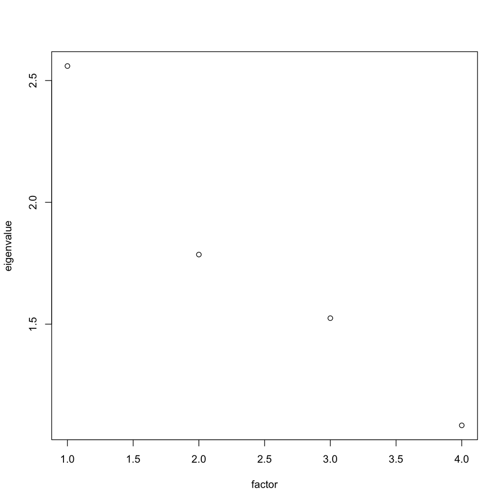

```
##
## Call:
## factanal(x = na.omit(UV[Q.Front]), factors = 3, scores = "regression",     rotation = "promax")
##
## Uniquenesses:
## UV1.Front UV2.Front UV3.Front  A1.Front  A2.Front IS1.Front IS2.Front
##      0.31      0.46      0.56      0.78      0.70      0.35      0.71
## IS3.Front IS4.Front IS5.Front IS6.Front  E1.Front HL1.Front
##      0.29      0.54      0.30      0.33      0.72      0.83
##
## Loadings:
##           Factor1 Factor2 Factor3
## IS3.Front  0.86
## IS5.Front  0.86
## IS6.Front  0.77
## A1.Front  -0.31    0.56    0.28
## IS1.Front  0.28    0.58
## IS2.Front -0.15    0.54   -0.12
## UV1.Front                  0.84
## UV2.Front  0.13            0.76
## UV3.Front          0.36   -0.45
## A2.Front   0.14    0.45
## IS4.Front  0.35    0.41
## E1.Front   0.19    0.46    0.21
## HL1.Front          0.33
##
##                Factor1 Factor2 Factor3
## SS loadings       2.46    1.77    1.66
## Proportion Var    0.19    0.14    0.13
## Cumulative Var    0.19    0.32    0.45
##
## Factor Correlations:
##         Factor1 Factor2 Factor3
## Factor1    1.00   -0.27   -0.54
## Factor2   -0.27    1.00    0.40
## Factor3   -0.54    0.40    1.00
##
## Test of the hypothesis that 3 factors are sufficient.
## The chi square statistic is 40.32 on 42 degrees of freedom.
## The p-value is 0.545
```

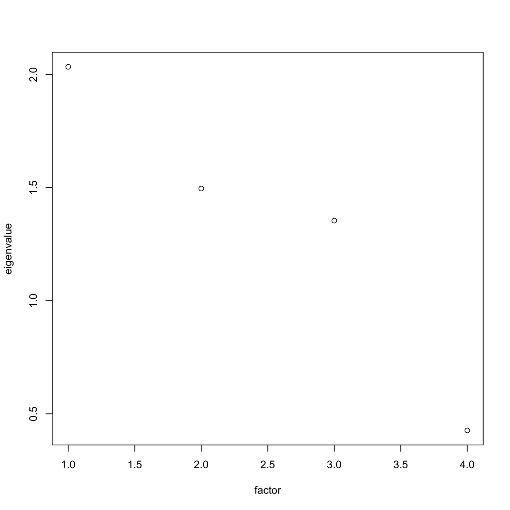

```
##
## Call:
## factanal(x = na.omit(UV[Q.Front]), factors = 3, scores = "regression",     rotation = "promax")
##
## Uniquenesses:
## UV1.Front UV2.Front  A2.Front IS1.Front IS2.Front IS3.Front IS5.Front
##      0.00      0.62      0.51      0.41      0.76      0.29      0.31
## IS6.Front
##      0.34
##
## Loadings:
##           Factor1 Factor2 Factor3
## IS3.Front  0.85
## IS5.Front  0.80
## IS6.Front  0.74   -0.12
## UV1.Front          1.05    0.13
## UV2.Front  0.14    0.56   -0.14
## A2.Front           0.17    0.77
## IS1.Front  0.28            0.58
## IS2.Front -0.13            0.50
##
##                Factor1 Factor2 Factor3
## SS loadings       2.04    1.45    1.23
## Proportion Var    0.25    0.18    0.15
## Cumulative Var    0.25    0.44    0.59
##
## Factor Correlations:
##         Factor1 Factor2 Factor3
## Factor1    1.00    0.16    0.50
## Factor2    0.16    1.00    0.52
## Factor3    0.50    0.52    1.00
##
## Test of the hypothesis that 3 factors are sufficient.
## The chi square statistic is 10.53 on 7 degrees of freedom.
## The p-value is 0.161
```

After considering Kaiser’s criterion (eigenvalues ≥ 1), a scree plot, and model fit indices, the results suggested a three factor model. According to Kaiser’s criterion, 5 factors are recommended. However, the fourth and fifth factors are not interpretable and only have one item. Therefore, we assessed three factors. The chi-square test of model fit supported the three factor solution, but not 2, $\chi^2$(7) = 10.53, $p =$ 0.16. The chi-square test is suitable for this sample of 119 (less than 500).

## EFA by Age group

### EFA for front younger

### EFA for front older

### EFA for back younger

### EFA for back older

## Factors

| 1 | 2 | 3 | 4 |
| --- | --- | --- | --- |
| 34 | 85 | 44 | 32 |
| 3 | 5 | 5 | 1 |
| 2 | 2 | 2 | 2 |
| 8 | 0 | 3 | 0 |

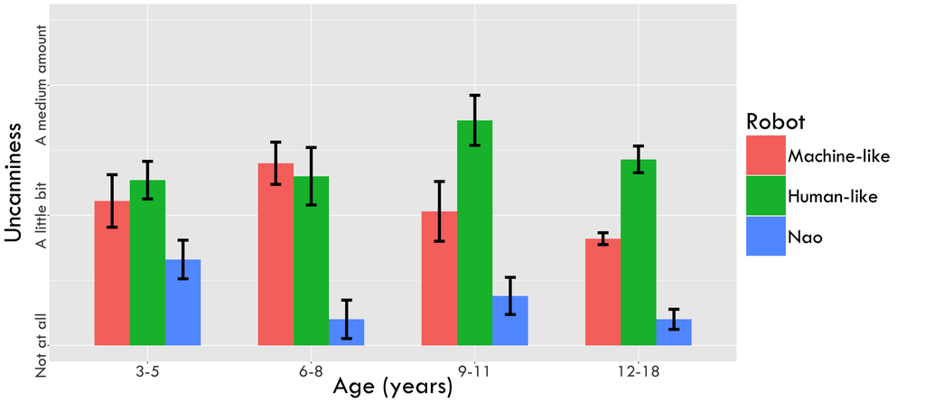

```
##
##  Welch Two Sample t-test
##
## data:  UV$UVindex.Back[which(UV$AgeGroup == 1 | UV$AgeGroup == 2)] and UV$UVindex.Front[which(UV$AgeGroup == 1 | UV$AgeGroup == 2)]
## t = 0.023507, df = 142.9, p-value = 0.9813
## alternative hypothesis: true difference in means is not equal to 0
## 95 percent confidence interval:
##  -0.3319846  0.3399754
## sample estimates:
## mean of x mean of y
##  2.291667  2.287671
```

```
## [1] 0.003903255
```

```
##
##  Welch Two Sample t-test
##
## data:  UV$UVindex.Back[which(UV$AgeGroup3 == 1)] and UV$UVindex.Front[which(UV$AgeGroup3 == 1)]
## t = -0.041562, df = 110.28, p-value = 0.9669
## alternative hypothesis: true difference in means is not equal to 0
## 95 percent confidence interval:
##  -0.3975506  0.3812177
## sample estimates:
## mean of x mean of y
##  2.237288  2.245455
```

```
## [1] 0.00780494
```

```
##
##  Welch Two Sample t-test
##
## data:  UV$UVindex.Back[which(UV$AgeGroup3 == 2)] and UV$UVindex.Front[which(UV$AgeGroup3 == 2)]
## t = -1.9404, df = 77.179, p-value = 0.05599
## alternative hypothesis: true difference in means is not equal to 0
## 95 percent confidence interval:
##  -0.82198568  0.01062205
## sample estimates:
## mean of x mean of y
##  2.181818  2.587500
```

```
## [1] 0.4270791
```

```
##
##  Welch Two Sample t-test
##
## data:  UV$UVindex.Back[which(UV$AgeGroup3 == 3)] and UV$UVindex.Front[which(UV$AgeGroup3 == 3)]
## t = -2.4221, df = 33.842, p-value = 0.02094
## alternative hypothesis: true difference in means is not equal to 0
## 95 percent confidence interval:
##  -1.12262578 -0.09815344
## sample estimates:
## mean of x mean of y
##  1.821429  2.431818
```

```
## [1] 0.7596551
```

```
##
##  Welch Two Sample t-test
##
## data:  UV$UVindex.Back[which(UV$AgeGroup == 3)] and UV$UVindex.Front[which(UV$AgeGroup == 3)]
## t = -2.5422, df = 37.601, p-value = 0.01526
## alternative hypothesis: true difference in means is not equal to 0
## 95 percent confidence interval:
##  -1.2486616 -0.1413677
## sample estimates:
## mean of x mean of y
##  2.032258  2.727273
```

```
## [1] 0.7412898
```

```
##
##  Welch Two Sample t-test
##
## data:  UV$UVindex.Back[which(UV$AgeGroup == 4)] and UV$UVindex.Front[which(UV$AgeGroup == 4)]
## t = -2.4221, df = 33.842, p-value = 0.02094
## alternative hypothesis: true difference in means is not equal to 0
## 95 percent confidence interval:
##  -1.12262578 -0.09815344
## sample estimates:
## mean of x mean of y
##  1.821429  2.431818
```

```
## [1] 0.7596551
```

```
##
##  Welch Two Sample t-test
##
## data:  UV$UVindex.Back[which(UV$AgeGroup5 == 1)] and UV$UVindex.Front[which(UV$AgeGroup5 == 1)]
## t = -0.53321, df = 47.903, p-value = 0.5964
## alternative hypothesis: true difference in means is not equal to 0
## 95 percent confidence interval:
##  -0.7620382  0.4425938
## sample estimates:
## mean of x mean of y
##  2.111111  2.270833
```

```
## [1] 0.1498671
```

```
##
##  Welch Two Sample t-test
##
## data:  UV$UVindex.Back[which(UV$AgeGroup5 == 2)] and UV$UVindex.Front[which(UV$AgeGroup5 == 2)]
## t = 0.44883, df = 60.141, p-value = 0.6552
## alternative hypothesis: true difference in means is not equal to 0
## 95 percent confidence interval:
##  -0.4076636  0.6435507
## sample estimates:
## mean of x mean of y
##  2.343750  2.225806
```

```
## [1] 0.1132696
```

```
##
##  Welch Two Sample t-test
##
## data:  UV$UVindex.Back[which(UV$AgeGroup5 == 3)] and UV$UVindex.Front[which(UV$AgeGroup5 == 3)]
## t = -0.86477, df = 42.771, p-value = 0.392
## alternative hypothesis: true difference in means is not equal to 0
## 95 percent confidence interval:
##  -0.7826132  0.3129162
## sample estimates:
## mean of x mean of y
##  2.333333  2.568182
```

```
## [1] 0.2561677
```

```
##
##  Welch Two Sample t-test
##
## data:  UV$UVindex.Back[which(UV$AgeGroup5 == 4)] and UV$UVindex.Front[which(UV$AgeGroup5 == 4)]
## t = -1.8595, df = 31.584, p-value = 0.0723
## alternative hypothesis: true difference in means is not equal to 0
## 95 percent confidence interval:
##  -1.28089713  0.05867491
## sample estimates:
## mean of x mean of y
##  2.000000  2.611111
```

```
## [1] 0.613006
```

```
##
##  Welch Two Sample t-test
##
## data:  UV$UVindex.Back[which(UV$AgeGroup5 == 5)] and UV$UVindex.Front[which(UV$AgeGroup5 == 5)]
## t = -2.4221, df = 33.842, p-value = 0.02094
## alternative hypothesis: true difference in means is not equal to 0
## 95 percent confidence interval:
##  -1.12262578 -0.09815344
## sample estimates:
## mean of x mean of y
##  1.821429  2.431818
```

```
## [1] 0.7596551
```

[figure not shown]

```
##
##  Welch Two Sample t-test
##
## data:  UV[which(UV$AgeGroup == 4), ]$Agency.Back and UV[which(UV$AgeGroup == 4), ]$Agency.Front
## t = -1.4982, df = 32.093, p-value = 0.1439
## alternative hypothesis: true difference in means is not equal to 0
## 95 percent confidence interval:
##  -0.62305819  0.09491967
## sample estimates:
## mean of x mean of y
##  1.190476  1.454545
```

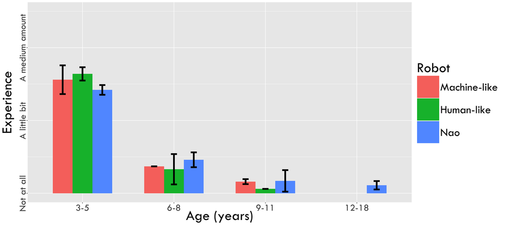

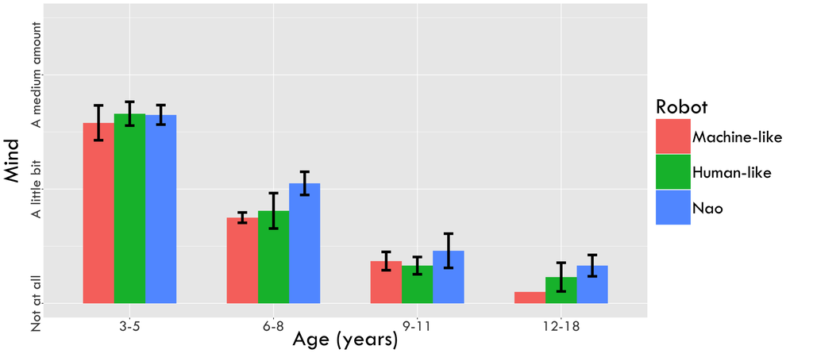

## Correlations

```
##
##  Pearson's product-moment correlation
##
## data:  UV$UVindex.Back and UV$Agency.Back
## t = -0.27088, df = 115, p-value = 0.787
## alternative hypothesis: true correlation is not equal to 0
## 95 percent confidence interval:
##  -0.2058408  0.1570012
## sample estimates:
##         cor
## -0.02525144
```

```
##
##  Pearson's product-moment correlation
##
## data:  UV$UVindex.Front and UV$Agency.Front
## t = -3.6429, df = 114, p-value = 0.0004072
## alternative hypothesis: true correlation is not equal to 0
## 95 percent confidence interval:
##  -0.4771349 -0.1493859
## sample estimates:
##        cor
## -0.3229079
```

```
##
##  Pearson's product-moment correlation
##
## data:  UV$UVindex.Back and UV$Exp.Back
## t = 0.66536, df = 115, p-value = 0.5072
## alternative hypothesis: true correlation is not equal to 0
## 95 percent confidence interval:
##  -0.1209665  0.2407529
## sample estimates:
##        cor
## 0.06192637
```

```
##
##  Pearson's product-moment correlation
##
## data:  UV$UVindex.Front and UV$Exp.Front
## t = -1.7803, df = 115, p-value = 0.07766
## alternative hypothesis: true correlation is not equal to 0
## 95 percent confidence interval:
##  -0.33533848  0.01830177
## sample estimates:
##        cor
## -0.1637753
```

```
##
##  Pearson's product-moment correlation
##
## data:  UV$Agency.Back and UV$Exp.Back
## t = 6.2401, df = 118, p-value = 7.084e-09
## alternative hypothesis: true correlation is not equal to 0
## 95 percent confidence interval:
##  0.3501328 0.6218357
## sample estimates:
##       cor
## 0.4981134
```

```
##
##  Pearson's product-moment correlation
##
## data:  UV$Agency.Front and UV$Exp.Front
## t = 5.923, df = 116, p-value = 3.301e-08
## alternative hypothesis: true correlation is not equal to 0
## 95 percent confidence interval:
##  0.3298502 0.6095439
## sample estimates:
##       cor
## 0.4818783
```

```
##
##  Pearson's product-moment correlation
##
## data:  UV.young$Agency.Back and UV.young$Exp.Back
## t = 3.8069, df = 72, p-value = 0.000293
## alternative hypothesis: true correlation is not equal to 0
## 95 percent confidence interval:
##  0.1995039 0.5832840
## sample estimates:
##       cor
## 0.4093422
```

```
##
##  Pearson's product-moment correlation
##
## data:  UV.young$Agency.Front and UV.young$Exp.Front
## t = 3.8312, df = 71, p-value = 0.0002726
## alternative hypothesis: true correlation is not equal to 0
## 95 percent confidence interval:
##  0.2031854 0.5879805
## sample estimates:
##       cor
## 0.4139042
```

```
##
##  Pearson's product-moment correlation
##
## data:  UV.old$Agency.Back and UV.old$Exp.Back
## t = 3.0968, df = 44, p-value = 0.0034
## alternative hypothesis: true correlation is not equal to 0
## 95 percent confidence interval:
##  0.1513129 0.6353084
## sample estimates:
##       cor
## 0.4230291
```

```
##
##  Pearson's product-moment correlation
##
## data:  UV.old$Agency.Front and UV.old$Exp.Front
## t = 1.7895, df = 43, p-value = 0.08058
## alternative hypothesis: true correlation is not equal to 0
## 95 percent confidence interval:
##  -0.03279944  0.51686088
## sample estimates:
##       cor
## 0.2632692
```

## Partial Correlations

```
##   X1  estimate   tvalue  df      p.value
## 1  1 0.3021069 3.442579 118 0.0007979889
```

```
##   X1  estimate   tvalue  df      p.value
## 1  1 0.3275737 3.734104 116 0.0002935606
```

```
##   X1 estimate   tvalue df    p.value
## 1  1 0.291374 2.584535 72 0.01177784
```

```
##   X1  estimate   tvalue df     p.value
## 1  1 0.3575845 3.226386 71 0.001897298
```

```
##   X1  estimate   tvalue df     p.value
## 1  1 0.3761408 2.692787 44 0.009986943
```

```
##   X1  estimate   tvalue df    p.value
## 1  1 0.2693042 1.833691 43 0.07362712
```

## ANOVAs

Anova Table (Type III tests)

|  | Sum Sq | Df | F value | Pr(>F) |
| --- | --- | --- | --- | --- |
| **(Intercept)** | 102.7 | 1 | 107 | 7.65e-21 |
| **Robot** | 0.6445 | 1 | 0.6718 | 0.4133 |
| **AgeGroup** | 1.445 | 1 | 1.506 | 0.2209 |
| **Robot:AgeGroup** | 2.616 | 1 | 2.727 | 0.1 |
| **Residuals** | 220.7 | 230 | NA | NA |

```
##                     eta.sq eta.sq.part          SS  df        MS         F
## Robot          0.002846974 0.002912438   0.6445112   1 0.6445112 0.6718174
## AgeGroup       0.006384116 0.006507366   1.4452656   1 1.4452656 1.5064975
## Robot:AgeGroup 0.011557326 0.011718656   2.6164009   1 2.6164009 2.7272506
## Residuals      0.974675761          NA 220.6515973 230 0.9593548        NA
##                        p
## Robot          0.4132673
## AgeGroup       0.2209291
## Robot:AgeGroup 0.1000136
## Residuals             NA
```

Anova Table (Type II tests)

|  | Sum Sq | Df | F value | Pr(>F) |
| --- | --- | --- | --- | --- |
| **Robot** | 3.111 | 1 | 3.282 | 0.07134 |
| **AgeGroup2** | 0.01767 | 1 | 0.01864 | 0.8915 |
| **Robot:AgeGroup2** | 5.246 | 1 | 5.535 | 0.01949 |
| **Residuals** | 218 | 230 | NA | NA |

```
##                       eta.sq  eta.sq.part           SS  df         MS
## Robot           1.374216e-02 1.406957e-02   3.11101380   1 3.11101380
## AgeGroup2       7.806149e-05 8.105524e-05   0.01767192   1 0.01767192
## Robot:AgeGroup2 2.317323e-02 2.349844e-02   5.24606383   1 5.24606383
## Residuals       9.629872e-01           NA 218.00549502 230 0.94784998
##                          F          p
## Robot           3.28217953 0.07134018
## AgeGroup2       0.01864422 0.89151082
## Robot:AgeGroup2 5.53469848 0.01948672
## Residuals               NA         NA
```

## Regression

```
##
##  Welch Two Sample t-test
##
## data:  UVindex by Robot
## t = 0.023507, df = 142.9, p-value = 0.9813
## alternative hypothesis: true difference in means is not equal to 0
## 95 percent confidence interval:
##  -0.3319846  0.3399754
## sample estimates:
##  mean in group Kaspar Back mean in group Kaspar Front
##                   2.291667                   2.287671
```

```
##
##  Welch Two Sample t-test
##
## data:  UVindex by Robot
## t = -2.5422, df = 37.601, p-value = 0.01526
## alternative hypothesis: true difference in means is not equal to 0
## 95 percent confidence interval:
##  -1.2486616 -0.1413677
## sample estimates:
##  mean in group Kaspar Back mean in group Kaspar Front
##                   2.032258                   2.727273
```

```
##
##  Welch Two Sample t-test
##
## data:  UVindex by Robot
## t = -2.4221, df = 33.842, p-value = 0.02094
## alternative hypothesis: true difference in means is not equal to 0
## 95 percent confidence interval:
##  -1.12262578 -0.09815344
## sample estimates:
##  mean in group Kaspar Back mean in group Kaspar Front
##                   1.821429                   2.431818
```

|  | Estimate | Std. Error | t value | Pr(>\|t\|) |
| --- | --- | --- | --- | --- |
| **Agency.C** | -0.5719 | 0.2252 | -2.54 | 0.01177 |
| **Exp.C** | -0.09115 | 0.2617 | -0.3483 | 0.728 |
| **Age** | -0.004604 | 0.003277 | -1.405 | 0.1614 |
| **RobotKaspar Front** | -0.4012 | 0.3839 | -1.045 | 0.297 |
| **Agency.C:Age** | 0.003443 | 0.00221 | 1.558 | 0.1206 |
| **Exp.C:Age** | 0.00191 | 0.003695 | 0.5168 | 0.6058 |
| **Age:RobotKaspar Front** | 0.00661 | 0.003545 | 1.865 | 0.06351 |
| **(Intercept)** | 2.709 | 0.3232 | 8.383 | 5.658e-15 |

full sample regression

| Observations | Residual Std. Error | $R^2$ | Adjusted $R^2$ |
| --- | --- | --- | --- |
| 233 | 0.9575 | 0.08217 | 0.05362 |

Table continues below

| Agency.C | Exp.C | Age | RobotKaspar Front | Agency.C:Age | Exp.C:Age |
| --- | --- | --- | --- | --- | --- |
| -0.581 | -0.09275 | -0.1724 | -0.2043 | 0.003498 | 0.001943 |

| Age:RobotKaspar Front |
| --- |
| 0.2475 |

|  | Estimate | Std. Error | t value | Pr(>\|t\|) |
| --- | --- | --- | --- | --- |
| **Agency.C** | -0.8308 | 0.4566 | -1.82 | 0.07103 |
| **Exp.C** | 0.1163 | 0.3948 | 0.2946 | 0.7688 |
| **Age** | 0.003218 | 0.007885 | 0.4081 | 0.6838 |
| **RobotKaspar Front** | 0.2696 | 0.7984 | 0.3376 | 0.7362 |
| **Agency.C:Age** | 0.006877 | 0.005547 | 1.24 | 0.2172 |
| **Exp.C:Age** | -0.0006764 | 0.005515 | -0.1226 | 0.9026 |
| **Age:RobotKaspar Front** | -0.003081 | 0.00986 | -0.3124 | 0.7552 |
| **(Intercept)** | 2.133 | 0.6635 | 3.215 | 0.00163 |

Younger sample regression

| Observations | Residual Std. Error | $R^2$ | Adjusted $R^2$ |
| --- | --- | --- | --- |
| 144 | 0.9996 | 0.08276 | 0.03555 |

Table continues below

| Agency.C | Exp.C | Age | RobotKaspar Front | Agency.C:Age | Exp.C:Age |
| --- | --- | --- | --- | --- | --- |
| -0.8188 | 0.1311 | 0.05592 | 0.1329 | 0.006778 | -0.0007624 |

| Age:RobotKaspar Front |
| --- |
| -0.05353 |

|  | Estimate | Std. Error | t value | Pr(>\|t\|) |
| --- | --- | --- | --- | --- |
| **Agency.C** | -0.3146 | 0.7326 | -0.4295 | 0.6687 |
| **Exp.C** | 9.053 | 4.469 | 2.026 | 0.04609 |
| **Age** | -0.04476 | 0.0218 | -2.054 | 0.04324 |
| **RobotKaspar Front** | 1.206 | 1.235 | 0.9772 | 0.3314 |
| **Agency.C:Age** | 0.001889 | 0.004993 | 0.3784 | 0.7061 |
| **Exp.C:Age** | -0.07499 | 0.03711 | -2.021 | 0.0466 |
| **Age:RobotKaspar Front** | -0.003411 | 0.008654 | -0.3942 | 0.6945 |
| **(Intercept)** | 7.332 | 2.636 | 2.781 | 0.006733 |

Older sample regression

| Observations | Residual Std. Error | $R^2$ | Adjusted $R^2$ |
| --- | --- | --- | --- |
| 89 | 0.8868 | 0.1677 | 0.09572 |

Table continues below

| Agency.C | Exp.C | Age | RobotKaspar Front | Agency.C:Age | Exp.C:Age |
| --- | --- | --- | --- | --- | --- |
| -0.2374 | 2.521 | -1.183 | 0.6505 | 0.001425 | -0.02089 |

| Age:RobotKaspar Front |
| --- |
| -0.09016 |

```
##
##  Pearson's product-moment correlation
##
## data:  UVindex.young$Experience and UVindex.young$Agency
## t = 5.2108, df = 142, p-value = 6.493e-07
## alternative hypothesis: true correlation is not equal to 0
## 95 percent confidence interval:
##  0.2537006 0.5295226
## sample estimates:
##       cor
## 0.4006499
```

```
##
##  Pearson's product-moment correlation
##
## data:  UVindex.old$Experience and UVindex.old$Agency
## t = 3.4548, df = 87, p-value = 0.0008533
## alternative hypothesis: true correlation is not equal to 0
## 95 percent confidence interval:
##  0.1499247 0.5181154
## sample estimates:
##       cor
## 0.3473366
```

|  | Estimate | Std. Error | t value | Pr(>\|t\|) |
| --- | --- | --- | --- | --- |
| **Agency.C** | 0.2106 | 0.05034 | 4.184 | 4.08e-05 |
| **Age.C** | -0.4114 | 0.04987 | -8.25 | 1.242e-14 |
| **Agency.C:Age.C** | -0.2258 | 0.05078 | -4.446 | 1.364e-05 |
| **(Intercept)** | 1.413 | 0.04938 | 28.61 | 1.444e-77 |

Fitting linear model: Experience ~ Agency.C * Age.C

| Observations | Residual Std. Error | $R^2$ | Adjusted $R^2$ |
| --- | --- | --- | --- |
| 233 | 0.6682 | 0.4291 | 0.4216 |

| Agency.C | Age.C | Agency.C:Age.C |
| --- | --- | --- |
| 0.2397 | -0.469 | -0.2569 |

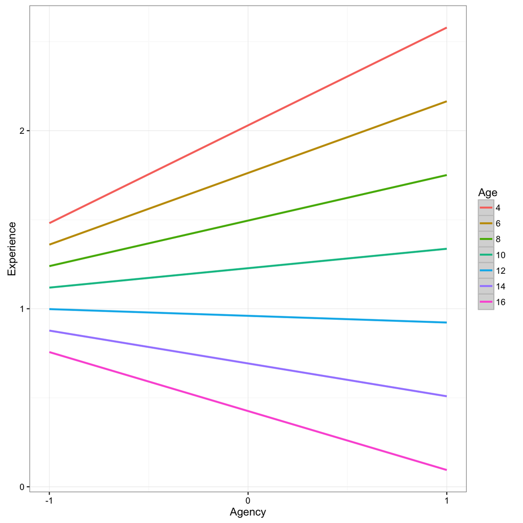

```
## lavaan (0.5-22) converged normally after  15 iterations
##
##                                                   Used       Total
##   Number of observations                           233         234
##
##   Estimator                                         ML
##   Minimum Function Test Statistic                0.000
##   Degrees of freedom                                 0
##   Minimum Function Value               0.0000000000000
##   P-value (Bollen-Stine Bootstrap)               1.000
##
## Parameter Estimates:
##
##   Information                                 Observed
##   Standard Errors                            Bootstrap
##   Number of requested bootstrap draws             1000
##   Number of successful bootstrap draws            1000
##
## Regressions:
##                    Estimate  Std.Err  z-value  P(>|z|)   Std.lv  Std.all
##   Exp ~
##     Agency.C  (c1)    0.211    0.056    3.779    0.000    0.211    0.240
##     Age.C     (c2)   -0.411    0.060   -6.813    0.000   -0.411   -0.469
##     AgencyXAg (c3)   -0.226    0.056   -4.033    0.000   -0.226   -0.228
##
## Variances:
##                    Estimate  Std.Err  z-value  P(>|z|)   Std.lv  Std.all
##    .Exp               0.439    0.053    8.210    0.000    0.439    0.571
##
## R-Square:
##                    Estimate
##     Exp               0.429
##
## Defined Parameters:
##                    Estimate  Std.Err  z-value  P(>|z|)   Std.lv  Std.all
##     mod0              0.549    0.098    5.592    0.000    0.549    0.582
##     mod1              0.403    0.071    5.646    0.000    0.403    0.434
##     mod2              0.256    0.056    4.546    0.000    0.256    0.285
##     mod3              0.109    0.062    1.746    0.081    0.109    0.137
##     mod4             -0.038    0.085   -0.442    0.659   -0.038   -0.011
##     mod5             -0.184    0.115   -1.598    0.110   -0.184   -0.160
##     mod6             -0.331    0.148   -2.233    0.026   -0.331   -0.308
```

```
##           lhs op        rhs label    est    se      z pvalue ci.lower
## 1         Exp  ~   Agency.C    c1  0.211 0.056  3.779  0.000    0.090
## 2         Exp  ~      Age.C    c2 -0.411 0.060 -6.813  0.000   -0.554
## 3         Exp  ~ AgencyXAge    c3 -0.226 0.056 -4.033  0.000   -0.349
## 4         Exp ~~        Exp        0.439 0.053  8.210  0.000    0.333
## 5    Agency.C ~~   Agency.C        0.996 0.000     NA     NA    0.996
## 6    Agency.C ~~      Age.C       -0.450 0.000     NA     NA   -0.450
## 7    Agency.C ~~ AgencyXAge       -0.134 0.000     NA     NA   -0.134
## 8       Age.C ~~      Age.C        0.999 0.000     NA     NA    0.999
## 9       Age.C ~~ AgencyXAge       -0.077 0.000     NA     NA   -0.077
## 10 AgencyXAge ~~ AgencyXAge        0.785 0.000     NA     NA    0.785
## 11       mod0 := c1+c3*-1.5  mod0  0.549 0.098  5.592  0.000    0.343
## 12       mod1 := c1+c3*-.85  mod1  0.403 0.071  5.646  0.000    0.260
## 13       mod2 :=  c1+c3*-.2  mod2  0.256 0.056  4.546  0.000    0.141
## 14       mod3 :=  c1+c3*.45  mod3  0.109 0.062  1.746  0.081   -0.046
```

[output cut: 21 more lines]

```
## [1] 4.015139
```

```
## [1] 6.008239
```

```
## [1] 8.001339
```

```
## [1] 9.99444
```

```
## [1] 11.98754
```

```
## [1] 13.98064
```

```
## [1] 15.97374
```

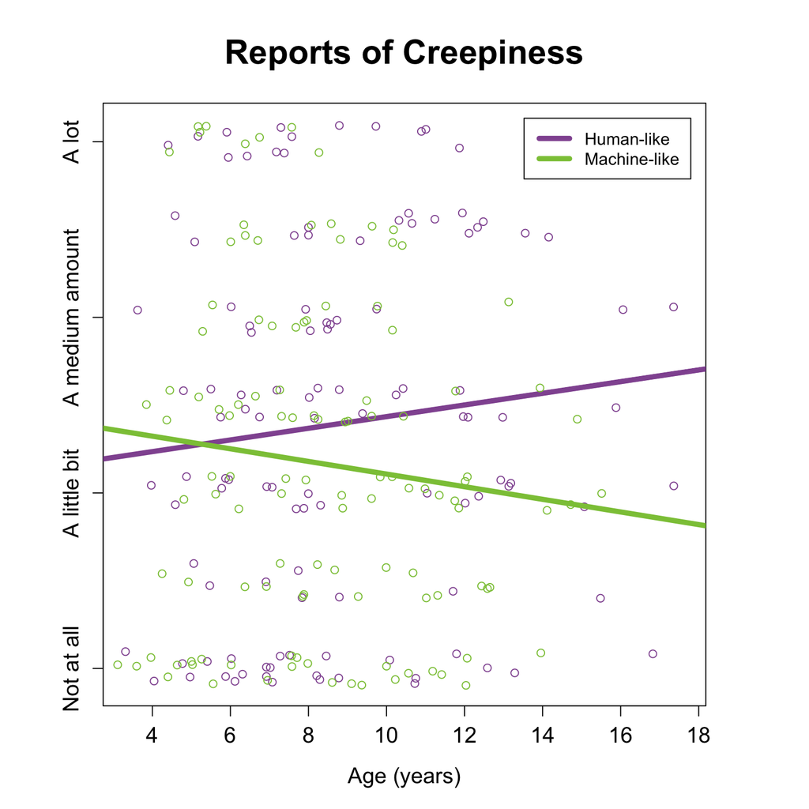

## Experience as mediator

### Sobel Test for Mediation

Test of experience as a mediator with robot appearance as predictor for children older than 9

|  | Sobel | Aroian | Goodman |
| --- | --- | --- | --- |
| **z.value** | -0.01445 | -0.01116 | -0.0254 |
| **p.value** | 0.9885 | 0.9911 | 0.9797 |

Test of experience as a mediator for all children with robot appearance as predictor for all children

|  | Sobel | Aroian | Goodman |
| --- | --- | --- | --- |
| **z.value** | 0.3988 | 0.2812 | NA |
| **p.value** | 0.69 | 0.7785 | NA |

### MacKinnon Mediation

|  | Estimate | Std. Error | t value | Pr(>\|t\|) |
| --- | --- | --- | --- | --- |
| **Exp.C** | 0.005325 | 0.3685 | 0.01445 | 0.9885 |
| **RobotKaspar Front** | 0.6132 | 0.1904 | 3.221 | 0.001801 |
| **(Intercept)** | 1.969 | 0.223 | 8.829 | 1.098e-13 |

Is the slope of Experience significantly different from zero?

| Observations | Residual Std. Error | $R^2$ | Adjusted $R^2$ |
| --- | --- | --- | --- |
| 89 | 0.8903 | 0.1092 | 0.08848 |

|  | Estimate | Std. Error | t value | Pr(>\|t\|) |
| --- | --- | --- | --- | --- |
| **RobotKaspar Front** | -0.06678 | 0.05492 | -1.216 | 0.2273 |
| **(Intercept)** | -0.4865 | 0.03861 | -12.6 | 2.563e-21 |

Is the slope of Robot significantly different from zero?

| Observations | Residual Std. Error | $R^2$ | Adjusted $R^2$ |
| --- | --- | --- | --- |
| 89 | 0.259 | 0.01671 | 0.005409 |

```
## [1] FALSE
```

The product of the coefficients ab = -410^{-4}, t = -0.14 (MacKinnon, Fairchild, & Fritz, 2007)

## Experience as a mediator for robot when controlling for age

Step 1: Show that the causal variable is correlated with the outcome

Step 2: Show that the causal variable is correlated with the mediator

Step 3: Show that the mediator affects the outcome variable

Step 4: To establish that M completely mediates the X-Y relationship, the effect of X on Y controlling for M (path c’) should be zero

### Baron & Kenny Mediation

|  | Estimate | Std. Error | t value | Pr(>\|t\|) |
| --- | --- | --- | --- | --- |
| **RobotKaspar Front** | 0.2284 | 0.129 | 1.771 | 0.07788 |
| **Age.C** | 0.01373 | 0.06463 | 0.2124 | 0.832 |
| **(Intercept)** | 2.168 | 0.09105 | 23.81 | 4.107e-64 |

Step 1: Show that the causal variable is correlated with the outcome

| Observations | Residual Std. Error | $R^2$ | Adjusted $R^2$ |
| --- | --- | --- | --- |
| 234 | 0.983 | 0.01395 | 0.005417 |

|  | Estimate | Std. Error | t value | Pr(>\|t\|) |
| --- | --- | --- | --- | --- |
| **RobotKaspar Front** | 0.03644 | 0.1093 | 0.3333 | 0.7392 |
| **Age.C** | -0.5596 | 0.05478 | -10.21 | 1.878e-20 |
| **(Intercept)** | -0.01822 | 0.07717 | -0.2361 | 0.8136 |

Step 2: Show that the causal variable is correlated with the mediator

| Observations | Residual Std. Error | $R^2$ | Adjusted $R^2$ |
| --- | --- | --- | --- |
| 234 | 0.8332 | 0.3117 | 0.3058 |

|  | Estimate | Std. Error | t value | Pr(>\|t\|) |
| --- | --- | --- | --- | --- |
| **Exp.C** | -0.07191 | 0.07765 | -0.926 | 0.3554 |
| **RobotKaspar Front** | 0.2311 | 0.1291 | 1.79 | 0.07472 |
| **Age.C** | -0.02651 | 0.0779 | -0.3403 | 0.7339 |
| **(Intercept)** | 2.167 | 0.09109 | 23.79 | 6.351e-64 |

Step 3: Show that the mediator affects the outcome variable

| Observations | Residual Std. Error | $R^2$ | Adjusted $R^2$ |
| --- | --- | --- | --- |
| 234 | 0.9833 | 0.01762 | 0.004803 |

### MacKinnon Mediation

|  | Estimate | Std. Error | t value | Pr(>\|t\|) |
| --- | --- | --- | --- | --- |
| **Exp.C** | -0.07191 | 0.07765 | -0.926 | 0.3554 |
| **RobotKaspar Front** | 0.2311 | 0.1291 | 1.79 | 0.07472 |
| **Age.C** | -0.02651 | 0.0779 | -0.3403 | 0.7339 |
| **(Intercept)** | 2.167 | 0.09109 | 23.79 | 6.351e-64 |

Is the slope of Experience significantly different from zero?

| Observations | Residual Std. Error | $R^2$ | Adjusted $R^2$ |
| --- | --- | --- | --- |
| 234 | 0.9833 | 0.01762 | 0.004803 |

|  | Estimate | Std. Error | t value | Pr(>\|t\|) |
| --- | --- | --- | --- | --- |
| **RobotKaspar Front** | 0.03644 | 0.1093 | 0.3333 | 0.7392 |
| **Age.C** | -0.5596 | 0.05478 | -10.21 | 1.878e-20 |
| **(Intercept)** | -0.01822 | 0.07717 | -0.2361 | 0.8136 |

Is the slope of Robot significantly different from zero?

| Observations | Residual Std. Error | $R^2$ | Adjusted $R^2$ |
| --- | --- | --- | --- |
| 234 | 0.8332 | 0.3117 | 0.3058 |

```
## [1] TRUE
```

The product of the coefficients ab = -0.0026, t = -4.81 (MacKinnon, Fairchild, & Fritz, 2007)

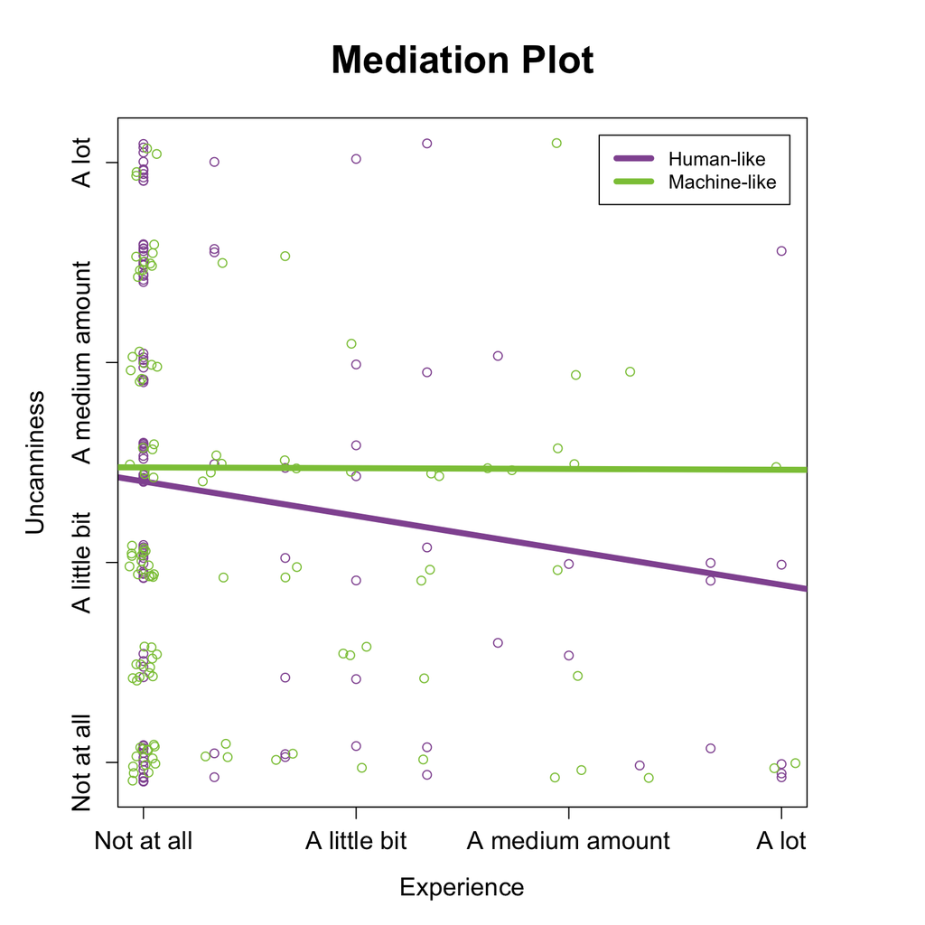

## Experience as a mediator for robot when controlling for age for only older children

### Baron & Kenny Mediation

Step 1: Show that the causal variable is correlated with the outcome

Step 2: Show that the causal variable is correlated with the mediator

Step 3: Show that the mediator affects the outcome variable

Step 4: To establish that M completely mediates the X-Y relationship, the effect of X on Y controlling for M (path c’) should be zero

|  | Estimate | Std. Error | t value | Pr(>\|t\|) |
| --- | --- | --- | --- | --- |
| **RobotKaspar Front** | 0.67 | 0.1962 | 3.415 | 0.0009762 |
| **Age.C** | -0.147 | 0.1473 | -0.9983 | 0.3209 |
| **(Intercept)** | 2.094 | 0.1834 | 11.42 | 6.511e-19 |

Step 1: Show that the causal variable is correlated with the outcome

| Observations | Residual Std. Error | $R^2$ | Adjusted $R^2$ |
| --- | --- | --- | --- |
| 89 | 0.8852 | 0.1194 | 0.09892 |

|  | Estimate | Std. Error | t value | Pr(>\|t\|) |
| --- | --- | --- | --- | --- |
| **RobotKaspar Front** | -0.03895 | 0.05682 | -0.6854 | 0.4949 |
| **Age.C** | -0.07163 | 0.04265 | -1.679 | 0.09672 |
| **(Intercept)** | -0.4245 | 0.05312 | -7.992 | 5.483e-12 |

Step 2: Show that the causal variable is correlated with the mediator

| Observations | Residual Std. Error | $R^2$ | Adjusted $R^2$ |
| --- | --- | --- | --- |
| 89 | 0.2564 | 0.04793 | 0.02579 |

|  | Estimate | Std. Error | t value | Pr(>\|t\|) |
| --- | --- | --- | --- | --- |
| **Exp.C** | -0.06181 | 0.3745 | -0.1651 | 0.8693 |
| **RobotKaspar Front** | 0.6676 | 0.1979 | 3.374 | 0.001118 |
| **Age.C** | -0.1515 | 0.1505 | -1.006 | 0.3172 |
| **(Intercept)** | 2.068 | 0.2435 | 8.491 | 5.789e-13 |

Step 3: Show that the mediator affects the outcome variable

| Observations | Residual Std. Error | $R^2$ | Adjusted $R^2$ |
| --- | --- | --- | --- |
| 89 | 0.8903 | 0.1197 | 0.08861 |

### MacKinnon Mediation

|  | Estimate | Std. Error | t value | Pr(>\|t\|) |
| --- | --- | --- | --- | --- |
| **Exp.C** | -0.06181 | 0.3745 | -0.1651 | 0.8693 |
| **RobotKaspar Front** | 0.6676 | 0.1979 | 3.374 | 0.001118 |
| **Age.C** | -0.1515 | 0.1505 | -1.006 | 0.3172 |
| **(Intercept)** | 2.068 | 0.2435 | 8.491 | 5.789e-13 |

Is the slope of Experience significantly different from zero?

| Observations | Residual Std. Error | $R^2$ | Adjusted $R^2$ |
| --- | --- | --- | --- |
| 89 | 0.8903 | 0.1197 | 0.08861 |

|  | Estimate | Std. Error | t value | Pr(>\|t\|) |
| --- | --- | --- | --- | --- |
| **RobotKaspar Front** | -0.03895 | 0.05682 | -0.6854 | 0.4949 |
| **Age.C** | -0.07163 | 0.04265 | -1.679 | 0.09672 |
| **(Intercept)** | -0.4245 | 0.05312 | -7.992 | 5.483e-12 |

Is the slope of Robot significantly different from zero?

| Observations | Residual Std. Error | $R^2$ | Adjusted $R^2$ |
| --- | --- | --- | --- |
| 89 | 0.2564 | 0.04793 | 0.02579 |

```
## [1] FALSE
```

The product of the coefficients ab = 0.0024, t = 1.53 (MacKinnon, Fairchild, & Fritz, 2007)

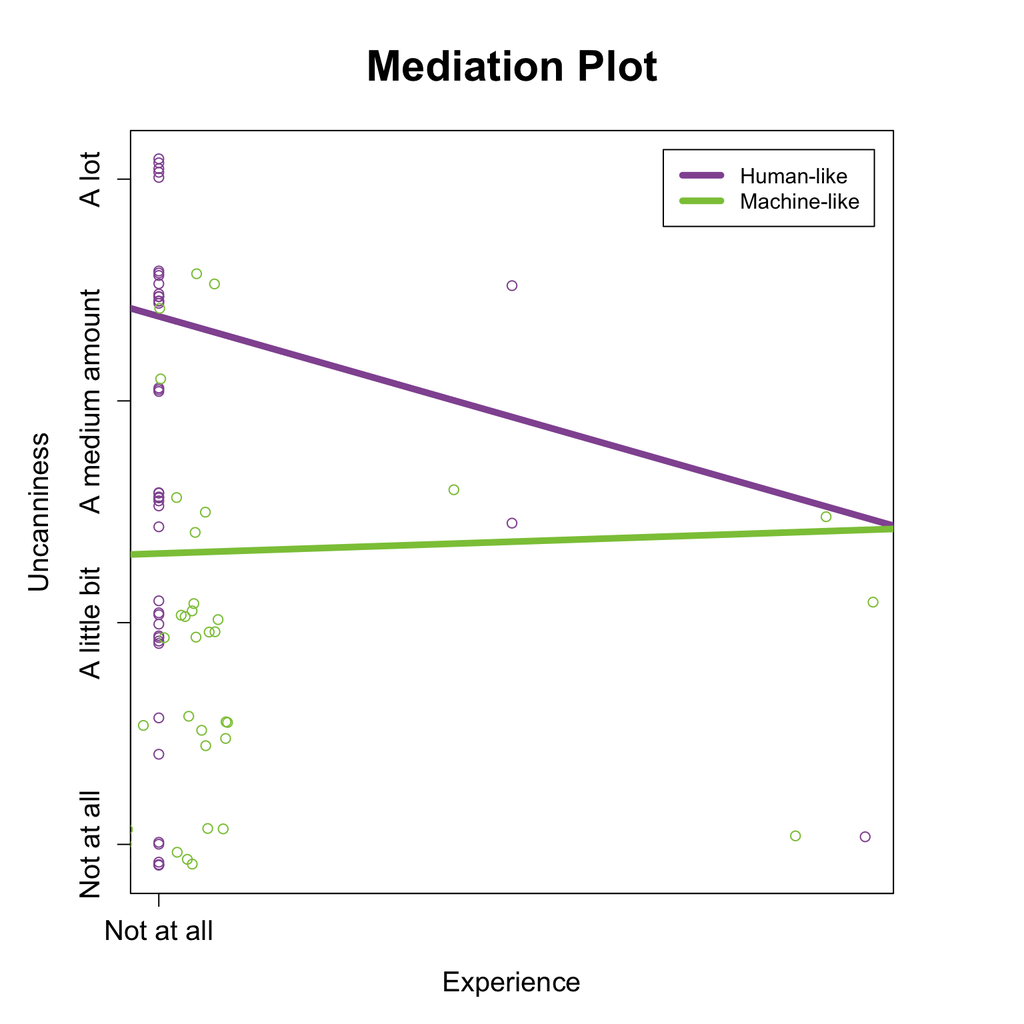

## Agency as mediator

### Sobel Test for Mediation

Test of Agency as a mediator with robot appearance as predictor for all children

|  | Sobel | Aroian | Goodman |
| --- | --- | --- | --- |
| **z.value** | -0.7138 | -0.6729 | -0.7632 |
| **p.value** | 0.4754 | 0.501 | 0.4453 |

Test of Agency as a mediator with age as predictor for all children

|  | Sobel | Aroian | Goodman |
| --- | --- | --- | --- |
| **z.value** | 2.6 | 2.581 | 2.62 |
| **p.value** | 0.009323 | 0.00986 | 0.008802 |

## Agency as a mediator of robot when controlling for age

Step 1: Show that the causal variable is correlated with the outcome

Step 2: Show that the causal variable is correlated with the mediator

Step 3: Show that the mediator affects the outcome variable

Step 4: To establish that M completely mediates the X-Y relationship, the effect of X on Y controlling for M (path c’) should be zero

### Baron & Kenny Mediation

|  | Estimate | Std. Error | t value | Pr(>\|t\|) |
| --- | --- | --- | --- | --- |
| **RobotKaspar Front** | 0.2284 | 0.129 | 1.771 | 0.07788 |
| **Age.C** | 0.01373 | 0.06463 | 0.2124 | 0.832 |
| **(Intercept)** | 2.168 | 0.09105 | 23.81 | 4.107e-64 |

Step 1: Show that the causal variable is correlated with the outcome

| Observations | Residual Std. Error | $R^2$ | Adjusted $R^2$ |
| --- | --- | --- | --- |
| 234 | 0.983 | 0.01395 | 0.005417 |

|  | Estimate | Std. Error | t value | Pr(>\|t\|) |
| --- | --- | --- | --- | --- |
| **RobotKaspar Front** | 0.1772 | 0.1173 | 1.51 | 0.1323 |
| **Age.C** | -0.4586 | 0.05868 | -7.815 | 1.954e-13 |
| **(Intercept)** | -0.08717 | 0.08259 | -1.056 | 0.2923 |

Step 2: Show that the causal variable is correlated with the mediator

| Observations | Residual Std. Error | $R^2$ | Adjusted $R^2$ |
| --- | --- | --- | --- |
| 233 | 0.8917 | 0.2117 | 0.2048 |

|  | Estimate | Std. Error | t value | Pr(>\|t\|) |
| --- | --- | --- | --- | --- |
| **Agency.C** | -0.2131 | 0.07131 | -2.988 | 0.003111 |
| **RobotKaspar Front** | 0.2788 | 0.1275 | 2.187 | 0.02974 |
| **Age.C** | -0.08766 | 0.07139 | -1.228 | 0.2207 |
| **(Intercept)** | 2.149 | 0.08953 | 24 | 1.892e-64 |

Step 3: Show that the mediator affects the outcome variable

| Observations | Residual Std. Error | $R^2$ | Adjusted $R^2$ |
| --- | --- | --- | --- |
| 233 | 0.9644 | 0.05234 | 0.03992 |

### MacKinnon Mediation

|  | Estimate | Std. Error | t value | Pr(>\|t\|) |
| --- | --- | --- | --- | --- |
| **RobotKaspar Front** | 0.2788 | 0.1275 | 2.187 | 0.02974 |
| **Agency.C** | -0.2131 | 0.07131 | -2.988 | 0.003111 |
| **Age.C** | -0.08766 | 0.07139 | -1.228 | 0.2207 |
| **(Intercept)** | 2.149 | 0.08953 | 24 | 1.892e-64 |

Fitting linear model: UVindex ~ Robot + Agency.C + Age.C

| Observations | Residual Std. Error | $R^2$ | Adjusted $R^2$ |
| --- | --- | --- | --- |
| 233 | 0.9644 | 0.05234 | 0.03992 |

|  | Estimate | Std. Error | t value | Pr(>\|t\|) |
| --- | --- | --- | --- | --- |
| **RobotKaspar Front** | 0.2788 | 0.1275 | 2.187 | 0.02974 |
| **Agency.C** | -0.2131 | 0.07131 | -2.988 | 0.003111 |
| **Age.C** | -0.08766 | 0.07139 | -1.228 | 0.2207 |
| **(Intercept)** | 2.149 | 0.08953 | 24 | 1.892e-64 |

Is the slope of Agency significantly different from zero?

| Observations | Residual Std. Error | $R^2$ | Adjusted $R^2$ |
| --- | --- | --- | --- |
| 233 | 0.9644 | 0.05234 | 0.03992 |

|  | Estimate | Std. Error | t value | Pr(>\|t\|) |
| --- | --- | --- | --- | --- |
| **RobotKaspar Front** | 0.1772 | 0.1173 | 1.51 | 0.1323 |
| **Age.C** | -0.4586 | 0.05868 | -7.815 | 1.954e-13 |
| **(Intercept)** | -0.08717 | 0.08259 | -1.056 | 0.2923 |

Is the slope of Robot significantly different from zero?

| Observations | Residual Std. Error | $R^2$ | Adjusted $R^2$ |
| --- | --- | --- | --- |
| 233 | 0.8917 | 0.2117 | 0.2048 |

```
## [1] TRUE
```

The product of the coefficients ab = -0.0378, t = -20.58 (MacKinnon, Fairchild, & Fritz, 2007)

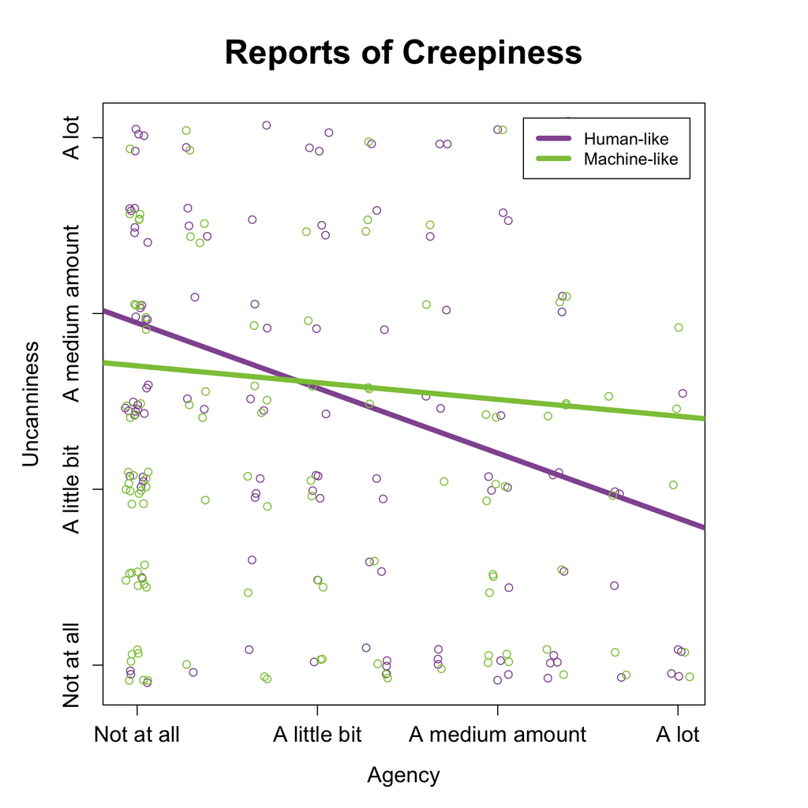

## Mind as mediator

### Sobel Test for Mediation

Test of Mind as a mediator with robot appearance as predictor for children older than 9

|  | Sobel | Aroian | Goodman |
| --- | --- | --- | --- |
| **z.value** | -0.1155 | -0.05681 | NA |
| **p.value** | 0.9081 | 0.9547 | NA |

### MacKinnon Mediation

```
##
## Reliability analysis
## Call: psych::alpha(x = UV[mind.back.factor])
##
##   raw_alpha std.alpha G6(smc) average_r S/N   ase mean  sd
##       0.78      0.79    0.78      0.38 3.7 0.022  1.8 0.8
##
##  lower alpha upper     95% confidence boundaries
## 0.74 0.78 0.83
##
##  Reliability if an item is dropped:
##          raw_alpha std.alpha G6(smc) average_r S/N alpha se
## IS1.Back      0.74      0.75    0.72      0.37 3.0    0.027
## IS2.Back      0.75      0.75    0.74      0.38 3.1    0.026
## A2.Back       0.76      0.76    0.74      0.39 3.2    0.025
## IS3.Back      0.75      0.75    0.71      0.37 3.0    0.025
## IS5.Back      0.76      0.77    0.75      0.39 3.3    0.024
## IS6.Back      0.74      0.74    0.72      0.37 2.9    0.026
##
##  Item statistics
##            n raw.r std.r r.cor r.drop mean  sd
## IS1.Back 120  0.73  0.71  0.64   0.57  1.9 1.2
## IS2.Back 120  0.71  0.70  0.61   0.55  1.9 1.2
## A2.Back  120  0.69  0.66  0.56   0.50  2.1 1.3
## IS3.Back 120  0.69  0.71  0.65   0.55  1.5 1.0
## IS5.Back 120  0.63  0.66  0.56   0.48  1.5 1.0
## IS6.Back 120  0.72  0.73  0.66   0.57  1.6 1.2
##
## Non missing response frequency for each item
##             1    2    3    4 miss
## IS1.Back 0.60 0.08 0.12 0.21  0.5
## IS2.Back 0.58 0.13 0.10 0.18  0.5
## A2.Back  0.51 0.12 0.12 0.26  0.5
## IS3.Back 0.78 0.09 0.02 0.12  0.5
## IS5.Back 0.78 0.06 0.06 0.11  0.5
## IS6.Back 0.76 0.03 0.02 0.18  0.5
```

```
##
## Reliability analysis
## Call: psych::alpha(x = UV[mind.front.factor])
##
##   raw_alpha std.alpha G6(smc) average_r S/N   ase mean   sd
##       0.79       0.8    0.81       0.4   4 0.021  1.8 0.79
##
##  lower alpha upper     95% confidence boundaries
## 0.75 0.79 0.83
##
##  Reliability if an item is dropped:
##           raw_alpha std.alpha G6(smc) average_r S/N alpha se
## IS1.Front      0.72      0.74    0.76      0.37 2.9    0.029
## IS2.Front      0.82      0.83    0.83      0.50 5.0    0.019
## A2.Front       0.77      0.78    0.79      0.42 3.6    0.024
## IS3.Front      0.75      0.75    0.74      0.37 3.0    0.026
## IS5.Front      0.74      0.75    0.75      0.37 2.9    0.027
## IS6.Front      0.74      0.75    0.75      0.37 2.9    0.027
##
##  Item statistics
##             n raw.r std.r r.cor r.drop mean   sd
## IS1.Front 119  0.80  0.79  0.73   0.67  2.0 1.22
## IS2.Front 118  0.50  0.47  0.30   0.27  2.1 1.20
## A2.Front  119  0.70  0.66  0.56   0.51  2.2 1.31
## IS3.Front 119  0.73  0.77  0.75   0.62  1.4 0.88
## IS5.Front 119  0.75  0.78  0.74   0.63  1.5 1.05
## IS6.Front 119  0.76  0.78  0.75   0.63  1.6 1.09
##
## Non missing response frequency for each item
##              1    2    3    4 miss
## IS1.Front 0.57 0.09 0.14 0.19 0.50
## IS2.Front 0.51 0.10 0.21 0.18 0.51
## A2.Front  0.48 0.08 0.15 0.29 0.50
## IS3.Front 0.83 0.07 0.02 0.08 0.50
## IS5.Front 0.76 0.08 0.04 0.13 0.50
## IS6.Front 0.77 0.04 0.04 0.14 0.50
```

```
##
## Reliability analysis
## Call: psych::alpha(x = UVindex[mind.factor])
##
##   raw_alpha std.alpha G6(smc) average_r S/N   ase mean  sd
##       0.65      0.65    0.49      0.49 1.9 0.045  1.8 0.8
##
##  lower alpha upper     95% confidence boundaries
## 0.56 0.65 0.74
##
##  Reliability if an item is dropped:
##            raw_alpha std.alpha G6(smc) average_r  S/N alpha se
## Agency          0.49      0.49    0.24      0.49   NA       NA
## Experience      0.24      0.49      NA        NA 0.49    0.046
##
##  Item statistics
##              n raw.r std.r r.cor r.drop mean   sd
## Agency     233  0.88  0.86   0.6   0.49  2.0 0.98
## Experience 234  0.85  0.86   0.6   0.49  1.5 0.88
```

```
##
##  Pearson's product-moment correlation
##
## data:  UV$Mind.Front and UV$Age
## t = -7.2844, df = 116, p-value = 4.213e-11
## alternative hypothesis: true correlation is not equal to 0
## 95 percent confidence interval:
##  -0.6728539 -0.4222315
## sample estimates:
##        cor
## -0.5602327
```

|  | Estimate | Std. Error | t value | Pr(>\|t\|) |
| --- | --- | --- | --- | --- |
| **Mind.C** | -0.1053 | 0.1905 | -0.5527 | 0.5819 |
| **RobotKaspar Front** | 0.6142 | 0.1884 | 3.259 | 0.001601 |
| **(Intercept)** | 1.9 | 0.1787 | 10.64 | 2.366e-17 |

Is the slope of Mind significantly different from zero?

| Observations | Residual Std. Error | $R^2$ | Adjusted $R^2$ |
| --- | --- | --- | --- |
| 89 | 0.8888 | 0.1123 | 0.0917 |

|  | Estimate | Std. Error | t value | Pr(>\|t\|) |
| --- | --- | --- | --- | --- |
| **RobotKaspar Front** | 0.01252 | 0.106 | 0.1181 | 0.9063 |
| **(Intercept)** | -0.6292 | 0.07454 | -8.44 | 6.269e-13 |

Is the slope of Robot significantly different from zero?

| Observations | Residual Std. Error | $R^2$ | Adjusted $R^2$ |
| --- | --- | --- | --- |
| 89 | 0.5001 | 0.0001602 | -0.01133 |

```
## [1] FALSE
```

The product of the coefficients ab = -0.0013, t = -1.11 (MacKinnon, Fairchild, & Fritz, 2007)

## Mind as a mediator for robot when controlling for age

### Baron & Kenny Mediation

Step 1: Show that the causal variable is correlated with the outcome

Step 2: Show that the causal variable is correlated with the mediator

Step 3: Show that the mediator affects the outcome variable

Step 4: To establish that M completely mediates the X-Y relationship, the effect of X on Y controlling for M (path c’) should be zero

|  | Estimate | Std. Error | t value | Pr(>\|t\|) |
| --- | --- | --- | --- | --- |
| **RobotKaspar Front** | 0.2284 | 0.129 | 1.771 | 0.07788 |
| **Age.C** | 0.01373 | 0.06463 | 0.2124 | 0.832 |
| **(Intercept)** | 2.168 | 0.09105 | 23.81 | 4.107e-64 |

Step 1: Show that the causal variable is correlated with the outcome

| Observations | Residual Std. Error | $R^2$ | Adjusted $R^2$ |
| --- | --- | --- | --- |
| 234 | 0.983 | 0.01395 | 0.005417 |

|  | Estimate | Std. Error | t value | Pr(>\|t\|) |
| --- | --- | --- | --- | --- |
| **RobotKaspar Front** | 0.1269 | 0.1071 | 1.185 | 0.2373 |
| **Age.C** | -0.5864 | 0.05359 | -10.94 | 1.051e-22 |
| **(Intercept)** | -0.06188 | 0.07543 | -0.8204 | 0.4129 |

Step 2: Show that the causal variable is correlated with the mediator

| Observations | Residual Std. Error | $R^2$ | Adjusted $R^2$ |
| --- | --- | --- | --- |
| 233 | 0.8144 | 0.3424 | 0.3367 |

|  | Estimate | Std. Error | t value | Pr(>\|t\|) |
| --- | --- | --- | --- | --- |
| **Mind.C** | -0.1962 | 0.07852 | -2.498 | 0.01318 |
| **RobotKaspar Front** | 0.266 | 0.128 | 2.079 | 0.03877 |
| **Age.C** | -0.105 | 0.07869 | -1.334 | 0.1836 |
| **(Intercept)** | 2.155 | 0.08996 | 23.96 | 2.515e-64 |

Step 3: Show that the mediator affects the outcome variable

| Observations | Residual Std. Error | $R^2$ | Adjusted $R^2$ |
| --- | --- | --- | --- |
| 233 | 0.9699 | 0.04151 | 0.02895 |

### MacKinnon Mediation

|  | Estimate | Std. Error | t value | Pr(>\|t\|) |
| --- | --- | --- | --- | --- |
| **Mind.C** | -0.1962 | 0.07852 | -2.498 | 0.01318 |
| **RobotKaspar Front** | 0.266 | 0.128 | 2.079 | 0.03877 |
| **Age.C** | -0.105 | 0.07869 | -1.334 | 0.1836 |
| **(Intercept)** | 2.155 | 0.08996 | 23.96 | 2.515e-64 |

Is the slope of Mind significantly different from zero?

| Observations | Residual Std. Error | $R^2$ | Adjusted $R^2$ |
| --- | --- | --- | --- |
| 233 | 0.9699 | 0.04151 | 0.02895 |

```
##            Mind.C RobotKaspar Front             Age.C
##        -0.1993176         0.1354003        -0.1068178
```

|  | Estimate | Std. Error | t value | Pr(>\|t\|) |
| --- | --- | --- | --- | --- |
| **RobotKaspar Front** | 0.1269 | 0.1071 | 1.185 | 0.2373 |
| **Age.C** | -0.5864 | 0.05359 | -10.94 | 1.051e-22 |
| **(Intercept)** | -0.06188 | 0.07543 | -0.8204 | 0.4129 |

Is the slope of Robot significantly different from zero?

| Observations | Residual Std. Error | $R^2$ | Adjusted $R^2$ |
| --- | --- | --- | --- |
| 233 | 0.8144 | 0.3424 | 0.3367 |

```
## RobotKaspar Front             Age.C
##        0.06359718       -0.58728625
```

```
## [1] TRUE
```

The product of the coefficients ab = -0.0249, t = -16.35 (MacKinnon, Fairchild, & Fritz, 2007)

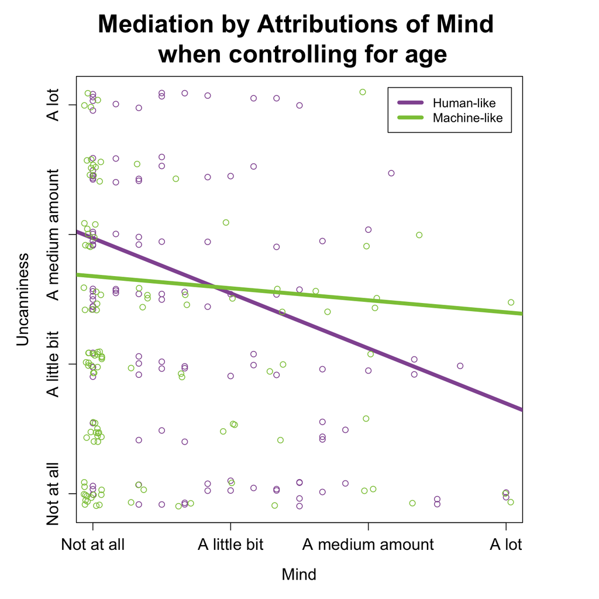

## Mind as a mediator for robot when controlling for age for only older children

### Baron & Kenny Mediation

Step 1: Show that the causal variable is correlated with the outcome

Step 2: Show that the causal variable is correlated with the mediator

Step 3: Show that the mediator affects the outcome variable

Step 4: To establish that M completely mediates the X-Y relationship, the effect of X on Y controlling for M (path c’) should be zero

|  | Estimate | Std. Error | t value | Pr(>\|t\|) |
| --- | --- | --- | --- | --- |
| **RobotKaspar Front** | 0.67 | 0.1962 | 3.415 | 0.0009762 |
| **Age.C** | -0.147 | 0.1473 | -0.9983 | 0.3209 |
| **(Intercept)** | 2.094 | 0.1834 | 11.42 | 6.511e-19 |

Step 1: Show that the causal variable is correlated with the outcome

| Observations | Residual Std. Error | $R^2$ | Adjusted $R^2$ |
| --- | --- | --- | --- |
| 89 | 0.8852 | 0.1194 | 0.09892 |

|  | Estimate | Std. Error | t value | Pr(>\|t\|) |
| --- | --- | --- | --- | --- |
| **RobotKaspar Front** | 0.04966 | 0.1106 | 0.4489 | 0.6547 |
| **Age.C** | -0.09558 | 0.08304 | -1.151 | 0.2529 |
| **(Intercept)** | -0.5465 | 0.1034 | -5.285 | 9.393e-07 |

Step 2: Show that the causal variable is correlated with the mediator

| Observations | Residual Std. Error | $R^2$ | Adjusted $R^2$ |
| --- | --- | --- | --- |
| 89 | 0.4991 | 0.01533 | -0.00757 |

|  | Estimate | Std. Error | t value | Pr(>\|t\|) |
| --- | --- | --- | --- | --- |
| **Mind.C** | -0.1306 | 0.1918 | -0.6809 | 0.4978 |
| **RobotKaspar Front** | 0.6765 | 0.1971 | 3.433 | 0.0009245 |
| **Age.C** | -0.1595 | 0.1489 | -1.071 | 0.287 |
| **(Intercept)** | 2.022 | 0.2118 | 9.551 | 4.15e-15 |

Step 3: Show that the mediator affects the outcome variable

| Observations | Residual Std. Error | $R^2$ | Adjusted $R^2$ |
| --- | --- | --- | --- |
| 89 | 0.888 | 0.1242 | 0.09326 |

### MacKinnon Mediation

|  | Estimate | Std. Error | t value | Pr(>\|t\|) |
| --- | --- | --- | --- | --- |
| **Mind.C** | -0.1306 | 0.1918 | -0.6809 | 0.4978 |
| **RobotKaspar Front** | 0.6765 | 0.1971 | 3.433 | 0.0009245 |
| **Age.C** | -0.1595 | 0.1489 | -1.071 | 0.287 |
| **(Intercept)** | 2.022 | 0.2118 | 9.551 | 4.15e-15 |

Is the slope of Mind significantly different from zero?

| Observations | Residual Std. Error | $R^2$ | Adjusted $R^2$ |
| --- | --- | --- | --- |
| 89 | 0.888 | 0.1242 | 0.09326 |

|  | Estimate | Std. Error | t value | Pr(>\|t\|) |
| --- | --- | --- | --- | --- |
| **RobotKaspar Front** | 0.04966 | 0.1106 | 0.4489 | 0.6547 |
| **Age.C** | -0.09558 | 0.08304 | -1.151 | 0.2529 |
| **(Intercept)** | -0.5465 | 0.1034 | -5.285 | 9.393e-07 |

Is the slope of Robot significantly different from zero?

| Observations | Residual Std. Error | $R^2$ | Adjusted $R^2$ |
| --- | --- | --- | --- |
| 89 | 0.4991 | 0.01533 | -0.00757 |

```
## [1] TRUE
```

The product of the coefficients ab = -0.0065, t = -3.57 (MacKinnon, Fairchild, & Fritz, 2007)

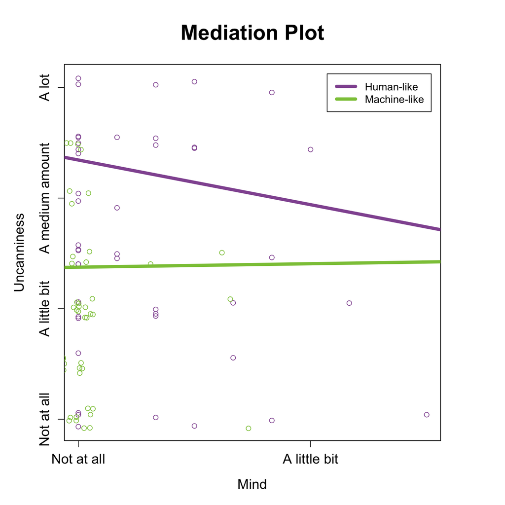

```
##
##      Multiple regression power calculation
##
##               u = 6
##               v = 233
##              f2 = 0.6569343
##       sig.level = 0.05
##           power = 1
```

```
##
##      One-sample t test power calculation
##
##               n = 89
##               d = 0.4081379
##       sig.level = 0.05
##           power = 0.9677026
##     alternative = two.sided
```

```
##
##  Paired t-test
##
## data:  UV.young$UVindex.Back and UV.young$UVindex.Nao
## t = 6.8856, df = 67, p-value = 2.425e-09
## alternative hypothesis: true difference in means is not equal to 0
## 95 percent confidence interval:
##  0.6840125 1.2424581
## sample estimates:
## mean of the differences
##               0.9632353
```

```
## [1] 0.8350057
```

```
##
##  Paired t-test
##
## data:  UV.9to11$UVindex.Back and UV.9to11$UVindex.Nao
## t = 2.668, df = 30, p-value = 0.01219
## alternative hypothesis: true difference in means is not equal to 0
## 95 percent confidence interval:
##  0.1361805 1.0251098
## sample estimates:
## mean of the differences
##               0.5806452
```

```
## [1] 0.4791886
```

```
##
##  Paired t-test
##
## data:  UV.old$UVindex.Back and UV.old$UVindex.Nao
## t = 2.7386, df = 12, p-value = 0.01798
## alternative hypothesis: true difference in means is not equal to 0
## 95 percent confidence interval:
##  0.1179289 1.0359173
## sample estimates:
## mean of the differences
##               0.5769231
```

```
## [1] 0.7595545
```